# Linear Regression and boostrap regression on insurance premiums based on age

Zackary Petrasek

September 13th, 2026

# 1 Introduction

```r
library(readr)

url <- "https://raw.githubusercontent.com/ZackaryPetrasek/STA321/main/homeworks/hw2/insurance.csv"

insurance_data <- read_csv(url)
library(fastDummies)
insure <- dummy_cols(insurance_data, select_columns = "region", remove_first_dummy = TRUE)
insure <- dummy_cols(insure, select_columns = "sex", remove_first_dummy = TRUE)
insure <- dummy_cols(insure, select_columns = "smoker", remove_first_dummy = TRUE)
```

This assignment is focused on linear regression, and more specifically bootstrapping linear regression. The dataset I choose to use is the “Medical Cost Personal Datasets” from Kaggle. The dataset has 6 explanatory variables and 1 response variable:

-Age: The age of the primary beneficiary. Discrete quantitative explanatory variable.

-Sex: The sex of the primary beneficiary. Two-level categorical explanatory variable with a 1 representing a man and 0 a woman.

-BMI: The BMI of the primary beneficiary. Quantitative explanatory variable.

-Smoker: If the primary beneficiary smokes or not. Two_level categorical variable with a 1 representing them smoking and 0 if they do not smoke.

-Children: How many children the primary beneficiary has. Discrete quantitative explanatory variable.

-Region: Region the primary beneficiary is from. Four-level categorical explanatory variable with northeast being the base level and northwest, southeast, and southwest all having their own dummy variable.

-Charges: The premium(or cost) of the insurance. Quantitative response variable.

The data comes from a machine learning textbook called “Machine Learning with R” by Brett Lantz. Online it says the textbook is known for using real-world datasets but does not specify further where this dataset came from before the textbook. The question I am looking to answer through this assignment is which explanatory variable has the strongest linear correlation with the response variable. Then use this variable to do both normal linear regression and bootstrapped linear regression. I will then continue to further use this data to do multiple variable linear regression and bootstrapped multiple-linear regression in future assignments. The dataset has more than enough observations to for both simple and multiple linear regression, as the dataset has 1338 observations and only 6 explanatory variables. With the minimum observations being 15 times the variable count the observations in this dataset are far greater than 90, which would be the minimum needed. I also added dummy variables to represent all of the categorical variables to make the dataset more suitable for regression.

# 2 Simple Linear Regression and Bootstrapped Simple Linear Regression

In this section I am going to look at the lineararity of all fo the explantaroy variables when plotted in a scatter plot with the response variables. Based on this I am going to choose a linear looking variable to conduct simple linear regression, and then bootstrapped simple linear regression to determine which of the two is more appropraite to use and why.

To start this section I am going to first look at all of the explanatory variables compared to the response variable, the premium of the insurance, to find the variable with the strongest linear correlation.

```r
plot(y=insure$charges, x=insure$age)
plot(y=insure$charges, x=insure$sex_male)
plot(y=insure$charges, x=insure$smoker_yes)
plot(y=insure$charges, x=insure$bmi)
plot(y=insure$charges, x=insure$children)
plot(y=insure$charges, x=insure$region_southwest)
plot(y=insure$charges, x=insure$region_southeast)
plot(y=insure$charges, x=insure$region_northwest)
```

[output not shown]

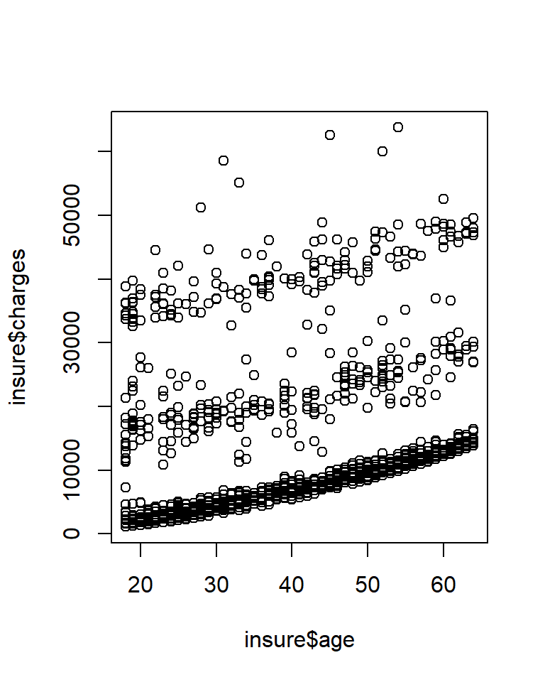

```r
plot(y=insure$charges, x=insure$age)
```

After looking at all of the variables the two that stick out to me the most are age and smoker. I am going to choose to continue to work with age as smoker is a two level categorical variable it would be very similar to just doing bootstrapping work on mean, which I already explored in the last assignment.

Due to the variable I have selected having a linear pattern I do not need to perform transformation on it, however, if transformation was needed, the explanatory variable is the one you should transform as we are interested in finding a pattern to predict the response variable, so it would not make sense to transform it for the model as we would then need to undo that transformation when using the model.

```r
agemodel <- lm(charges ~ age, data=insure)
summary(agemodel)
```

```
##
## Call:
## lm(formula = charges ~ age, data = insure)
##
## Residuals:
##    Min     1Q Median     3Q    Max
##  -8059  -6671  -5939   5440  47829
##
## Coefficients:
##             Estimate Std. Error t value Pr(>|t|)
## (Intercept)   3165.9      937.1   3.378 0.000751 ***
## age            257.7       22.5  11.453  < 2e-16 ***
## ---
## Signif. codes:  0 '***' 0.001 '**' 0.01 '*' 0.05 '.' 0.1 ' ' 1
##
## Residual standard error: 11560 on 1336 degrees of freedom
## Multiple R-squared:  0.08941,    Adjusted R-squared:  0.08872
## F-statistic: 131.2 on 1 and 1336 DF,  p-value: < 2.2e-16
```

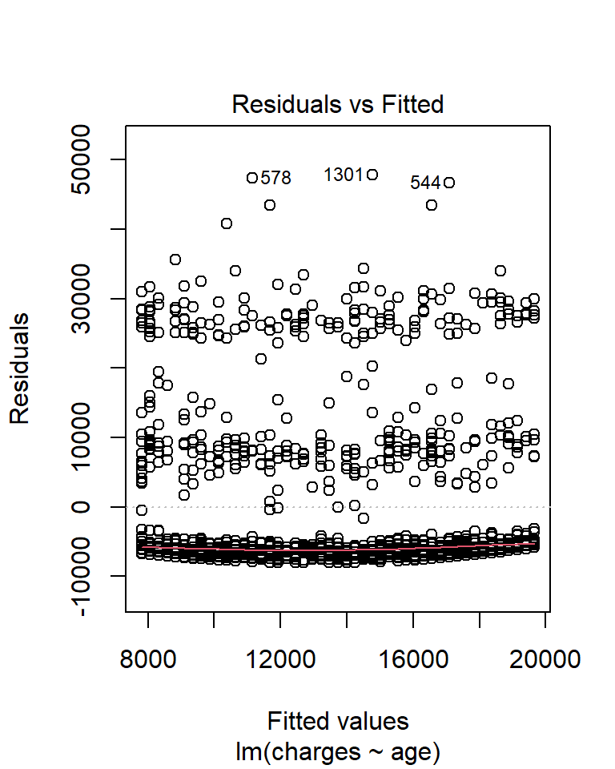

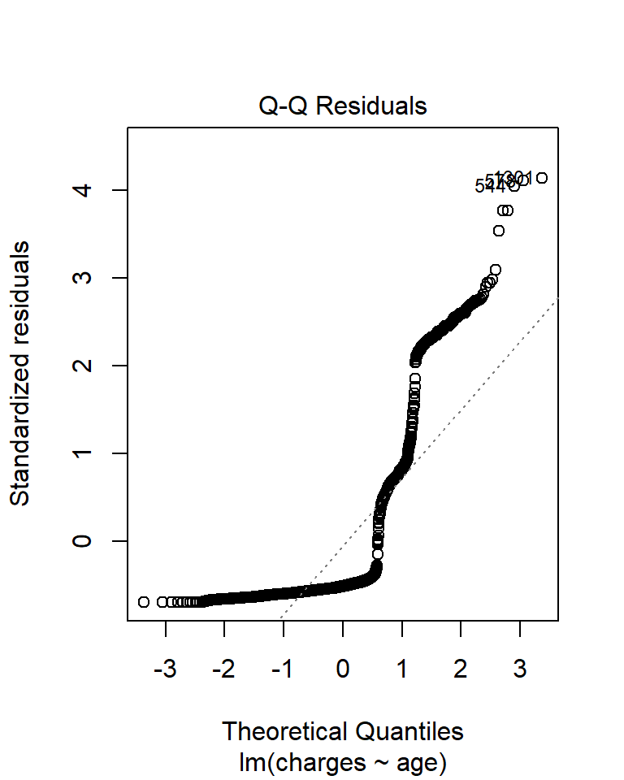

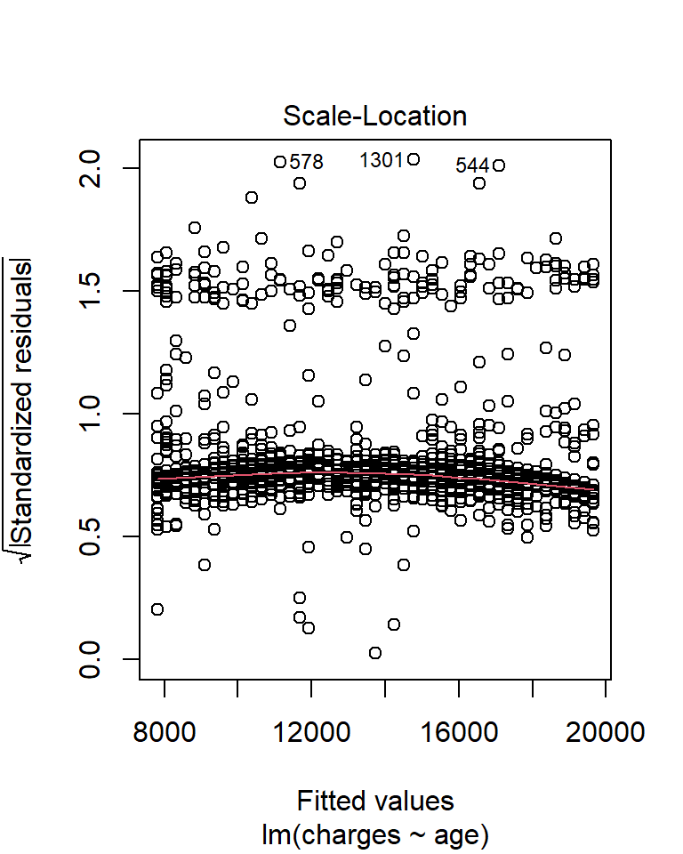

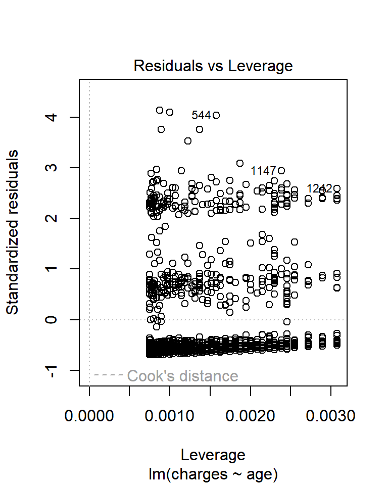

```r
plot(agemodel)
```

```r
library(pander)
bs.0 <- NULL
bs.1 <- NULL
vector.id <- 1:length(insure$charges)
for (i in 1:1000) {
  bs.id <- sample(vector.id, length(insure$charges), replace=TRUE)
bs.cost <- insure$charges[bs.id]
bs.age <- insure$age[bs.id]
bs.model <- lm(bs.cost ~ bs.age)
bs.0[i]<- coef(bs.model)[1]
bs.1[i] <- coef(bs.model)[2]
}
bs.0.ci <-quantile(bs.0, c(0.025, 0.975), type =2)
bs.1.ci <-quantile(bs.1, c(0.025, 0.975), type =2)
bs.coef <- data.frame(rbind(bs.0.ci, bs.1.ci))
names(bs.coef) <- c("2.5%", "97.5%")
pander(bs.coef, caption="Bootstrap confience intervals of regression coefficients")
```

Bootstrap confience intervals of regression coefficients

|  | 2.5% | 97.5% |
| --- | --- | --- |
| **bs.0.ci** | 1364 | 5097 |
| **bs.1.ci** | 211.5 | 305.4 |

# 3 Results